# Bruhn_A11_3

A11.18 モーメント分配法

ここで、節点Cを考えます。  
不釣合いモーメントは $-6.18$ です。釣合わせるために、CBへ $6.18 \times 150/190 = 4.88$ 分配します。Bへの到達モーメントは $2.44$ となり、CDへは $6.18 \times 40/190 = 1.30$ 分配します。Dへの到達モーメントは $0.65$ です。

この釣合わせと到達の処理を、不釣合いモーメントが無視できる大きさになるまで、節点BとCに対して繰り返します。  
Fig. A11.34（※前図参照）は4サイクルが完了した状態を示しています。計算尺の比率を 150/190 に設定しておくことで、節点BとCにおける不釣合いモーメントを非常に素早く書き留めながら、分配と到達を交互に繰り返すことができます。節点AとDは固定端と仮定されているため、モーメントを吸収しますが、到達モーメントを他に送り出すことはありません。

Fig. A11.35 は、骨組の各部分の自由体図を示しています。端部モーメントは Fig. A11.34 の結果から得られたものです。  
部材ABを自由体として考えます。水平反力 $H_B$ を求めるために、点Aの回りのモーメントの和を計算します。

$$\Sigma M_A = 300 \times 25 \times 12.5 + 11750 - 17570 - 25 H_B = 0$$

したがって、

$$H_B = 87930 / 25 = 3517 \text{ lb.}$$

次に、部材CDを自由体として考えます。  
$H_C$ を求めるために、Dの回りのモーメントの和を計算します。

$$\Sigma M_D = 1530 + 770 - 25 H_C = 0 \quad \text{したがって、} H_C = 89 \text{ lb.}$$

これらの水平力を、Fig. A11.35 の上部に示すように、頂部部材BCに自由体として作用させます。横移動を防ぐために Fig. A11.34 で追加された点Cにおける仮想の反力 $R_C$ も示されています。 $R_C$ を求めるために、 $\Sigma F_h = 0$ とします。

$$\Sigma F_h = 3517 + 89 - R_C = 0 \quad \text{したがって、} R_C = 3606 \text{ lb.}$$

3606 lb の外部反力は実際には存在しないため、これを取り除き、骨組の横移動による曲げモーメントを求める必要があります。換言すれば、骨組は、骨組の曲げによって $3606 \text{ lb}$ に等しい垂直脚上端の水平せん断反力が発生するまで横移動します。

### 横移動による曲げモーメント

骨組が Fig. A11.36 に示すように、上部節点の回転を伴わずに横移動すると仮定します。回転に対して端部が固定された梁の一端の横方向移動によって生じる端部モーメントは、横方向移動を $d$ とすると $6EId / L^2$ に等しいことが Art. A11.8 で証明されました。Fig. A11.36 において、荷重 $P$ は両方の垂直部材にその上端で同じ水平変位を生じさせるため、この変位による端部モーメントは $EI / L^2$ に比例します。

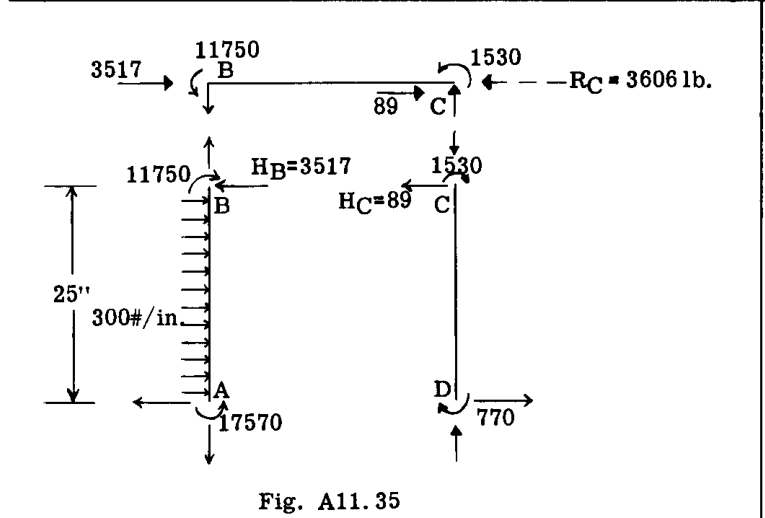

Fig. A11.35

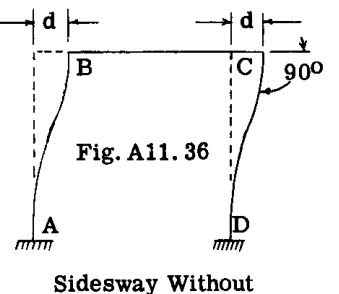

Fig. A11.36

私たちの構造物では、各垂直部材の $EI$ と $L$ が等しいため、固定端モーメントは各部材で同じ大きさになります。したがって、便宜上、横移動によって $10,000 \text{ ft.lbs.}$ の固定端モーメントが発生すると仮定します。ここで、Fig. A11.37 に示すように上部節点の回転を許容するモーメント分配法を使用します。手順は Fig. A11.34 の手順と類似しています。  
例えば、節点Bを考慮することから計算を始めます。不釣合いモーメントは $-10$ です。これは、BCに $10 \times 150/190 = 7.89$ 、残りの $2.11$ をBAに分配することで釣り合わされます。  
到達モーメントは、Cへ $7.89/2 = 3.95$ 、Aへ $2.11/2 = 1.06$ となります。荷重と構造の対称性により、節点Cにおける分配および到達モーメントは節点Bにおけるものと同一になるため、これらの節点での計算を示す必要はありません。CからBへの到達モーメントは、BからCへの到達モーメントと同一になります。Fig. A11.37 は、二重線の下に示される最終端部モーメントを得るために5サイクルが実行されたことを示しています。

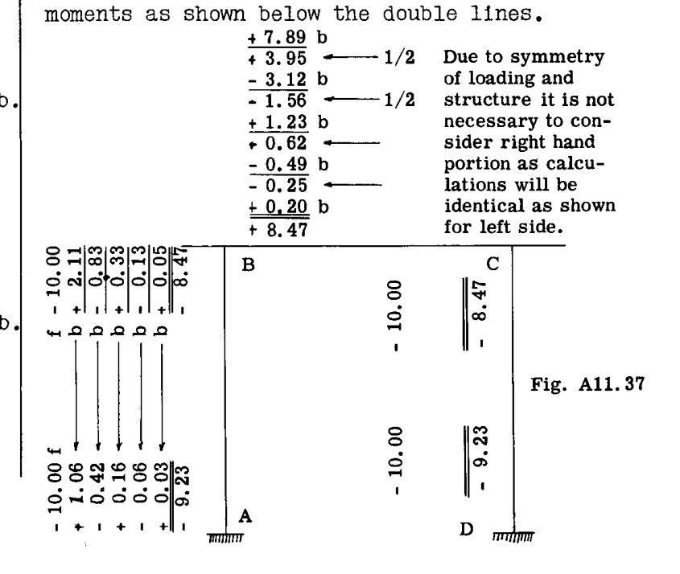

Fig. A11.37

All.19

Fig. A11.38 は、Fig. A11.37 で求められた端部モーメントを持つ骨組の垂直部材の自由体図を示しています。せん断反力 $H_B$ と $H_C$ はそれぞれ $(8470 + 9230)/25 = 708 \text{ lb}$ に等しくなります。これらのせん断反力は、Fig. A11.38 に示す部材BCの自由体に作用させます。平衡状態を得るためには、水平力の総和がゼロでなければなりません。したがって、Fig. A11.38 に示すように、右向きに作用する $P = 708 + 708 = 1416 \text{ lb}$ となります。Fig. A11.35 における反力 $R_C = -3606$ を相殺する必要があり、Fig. A11.37 のモーメントによって生じた相殺力 $P$ は $1416 \text{ lb}$ であるため、Fig. A11.37 の値に $3606/1416 = 2.545$ の係数を乗じる必要があることは明らかです。したがって、最終的な曲げモーメントの値は、Fig. A11.34 の値に Fig. A11.37 の値の $2.545$ 倍を加えたものに等しくなります。Fig. A11.39 はその結果を示し、Fig. A11.40 は最終モーメント図を示しています。

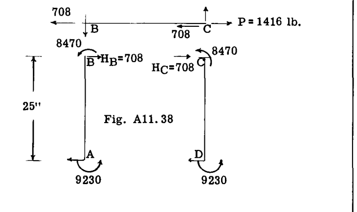

Fig. A11.38

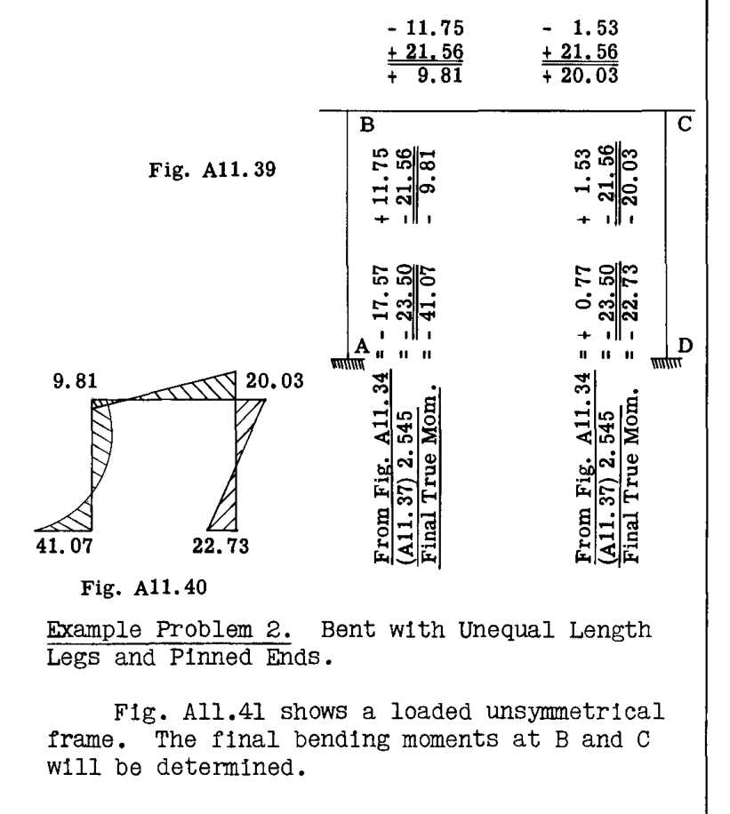

Fig. A11.39

[figure not shown]

## 例題 2. 長さが異なり端部がピン支持された骨組

Fig. A11.41 は、荷重を受けた非対称の骨組を示しています。BおよびCにおける最終曲げモーメントを決定します。

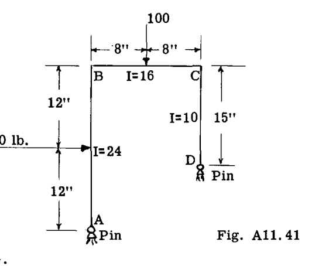

Fig. A11.41

### 解答

相対剛度係数：

$$K_{BA} = \frac{3I}{L} = \frac{3 \times 24}{24} = 3, \quad K_{BC} = \frac{4I}{L} = \frac{4 \times 16}{16} = 4$$

$$K_{CD} = \frac{3I}{L} = \frac{3 \times 10}{15} = 2$$

各節点BおよびCにおける各部材の分配率（ $K/\Sigma K$ に等しい）は、Fig. A11.41a の小さな正方形の中に記録されています。

固定端モーメント：  
部材ABについて $= PL/8 = 100 \times 24 / 8 = 300 \text{ in.lb.}$  
部材BCについて $= PL/8 = 100 \times 16 / 8 = 200$

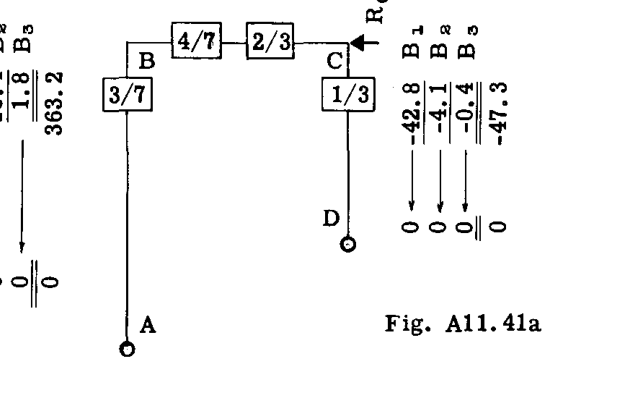

Fig. A11.41a

All.20 モーメント分配法

端部モーメントが既知であれば、Fig. A11.41b に示す各部材の自由体を考慮して反力 $R_C$ を計算できます。

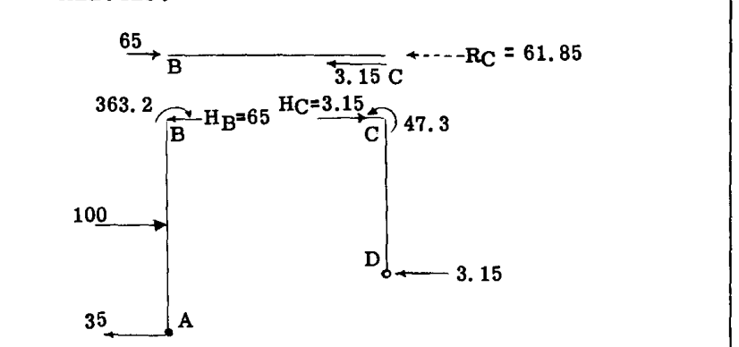

Fig. A11.41b

$H_C$ を求めるために、Dの回りのモーメントの和を計算します。

$$-47.3 + 15 H_C = 0, \quad H_C = 3.15$$

これらのせん断反力を部材BCに作用させ、水平力の釣合いを記述すると、 $R_C = 65 - 3.15 = 61.85 \text{ lb.}$ となります。ここで、この反力 $R_C$ を排除し、骨組に横移動を許容する必要があります。

骨組は固定端支持であり、点Cにおける未知の水平力 $P$ が骨組を横に移動させると仮定します。BおよびCの等しい水平変位に対する固定端モーメントは、垂直部材の $EI/L^2$ に比例します。

部材ABについて、

$$\frac{I}{L^2} = \frac{24}{24^2} = .0417$$

部材DCについて、

$$\frac{I}{L^2} = \frac{10}{15^2} = .0445$$

便宜上、ABの固定端モーメントを $417 \text{ in.lb.}$ 、DCの固定端モーメントを $445$ と仮定します。仮定された固定端は、Fig. A11.41c に示すモーメント分配プロセスによって排除されます。節点釣合わせの順序は ABDCBCBC でした。

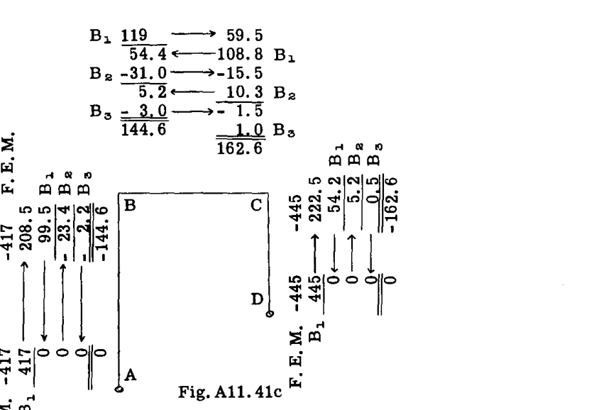

Fig. A11.41c

Fig. A11.41d は、BおよびCにおける垂直部材のせん断反力を示しています。これらの力を頂部部材に反転させて作用させると、 $6.02 + 10.85 = 16.87 \text{ lb.}$ の不釣合い力が示されます。したがって、横移動によって骨組に生じた曲げモーメントを発生させるためには、力 $P = 16.87$ が必要でした。

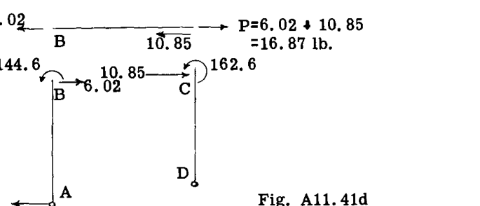

Fig. A11.41d

反力 $R_C = 61.85$ を相殺するためには、Fig. A11.41c のモーメントの $61.85/16.87 = 3.67$ 倍が必要となります。したがって、最終的な曲げモーメントは、Fig. A11.41a の値に Fig. A11.41c の値の $3.67$ 倍を加えたものに等しくなります。Fig. A11.41e はその結果を示しています。曲げモーメント図、せん断力図、および軸荷重は、単純な静力学の問題として得られます。

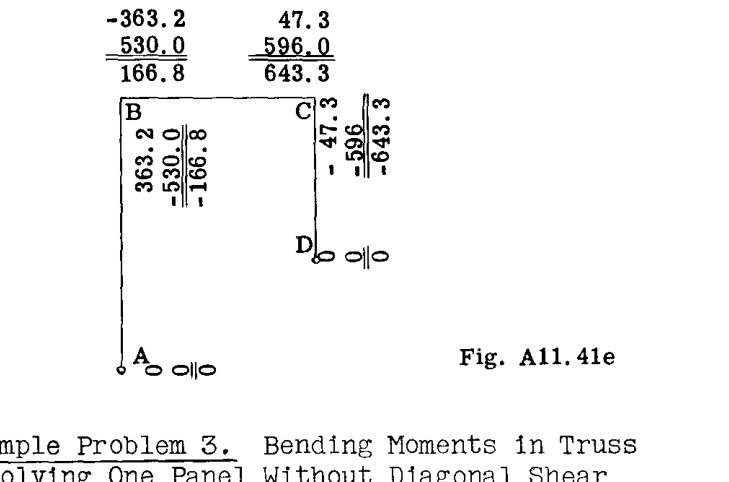

Fig. A11.41e

## 例題 3. 斜めせん断部材を持たない1パネルを含むトラスの曲げモーメント

航空機構造において、1つまたは複数のトラスパネルから斜め部材を省略しなければならないトラスが頻繁に使用されます。このようなパネルにかかる外部せん断荷重は、トラス弦部材の曲げによって負担されなければなりません。Fig. A11.42 は、中央パネルに斜め部材を持たない3パネルトラスを示しています。トラス部材の曲げモーメントを決定します。

All.21

荷重は図に示す通りです。

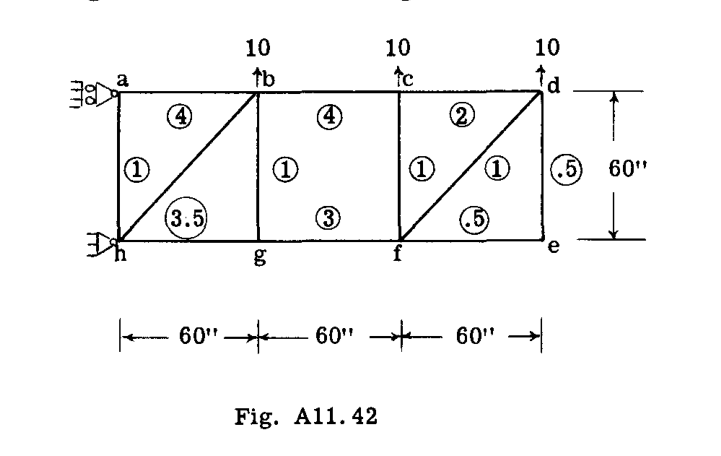

Fig. A11.42

### 解答

各部材の相対慣性モーメント値は、Fig. A11.42 のトラスの丸の中に示されています。  
各節点における各部材への分配率は、 $K/\Sigma K$ として計算されます。その値は Fig. A11.43 の各部材の角丸の中に記録されています。剛性係数 $K$ は部材の $I/L$ に比例します。  
例えば、節点Cについては：

$$\Sigma K = \Sigma \frac{I}{L} = \frac{4}{60} + \frac{2}{60} + \frac{1}{60} = \frac{7}{60}$$

分配率は次のようになります：  
部材cbに対して $= 4/7 = .57$  
部材cfに対して $= 1/7 = .14$  
部材cdに対して $= 2/7 = .29$

この問題では、節点間の部材に作用する荷重はありません。中央トラスパネルの右側にかかる外部せん断荷重（ $10 + 10 = 20$ に等しい）は、トラス弦部材の曲げによって中央パネルを通過しなければなりません。この曲げにより、中央トラスは、20に等しい抵抗せん断力が発生するまで横移動または変位します。

中央のトラスパネルは、節点b、c、f、gにおいて固定されていると仮定します。この仮定された固定端トラスの右端に上向きの変位を与えます。この変位により、部材bcおよびgfに固定端モーメントが発生し、これは各部材の $I/L^2$ に比例します。 $L$ は各部材で同じであるため、固定端モーメントは部材の $I$ に比例します。

$$I_{bc} = 4, \quad I_{gf} = 3$$

したがって、部材gfの固定端モーメントは、部材bcのモーメントの75%になります。

ここで、中央トラスの仮想の固定支持を取り除き、Fig. A11.43 に詳細を示すモーメント分配プロセスによって釣合い状態まで回転させます。

最初のステップは、符号に注意して、部材bcの両端に100、部材gfの両端に75の仮定固定端モーメントを記録することです。モーメント分配プロセスは節点Cから開始されます。不釣合いモーメントは100（または静的釣合いのために $-100$ が必要）です。節点Cの分配率を使用すると、 $-57$ がcbへ、 $-29$ がcdへ、 $-14$ がcfへ分配されます。これらの数値の下に短い線が引かれます。これらの釣合わせモーメントの50%が、各部材の他端へ到達モーメントとして伝達されます。このプロセスは、残りの不釣合いモーメントが無視できるようになるまで、各節点で繰り返されます。Fig. A11.43 において、節点釣合わせの順序は cfdebghacfdebghacfdebg でした。この順序に従えば、Fig. A11.43 の数値を検証できるはずです。

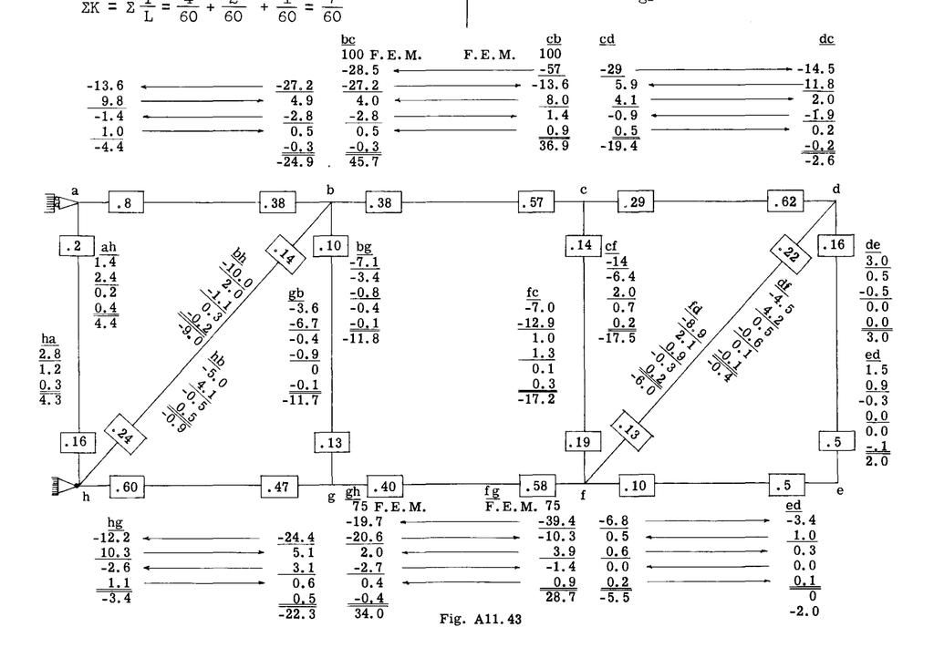

Fig. A11.43

All.22 モーメント分配法

Fig. A11.44 は、Fig. A11.43 からの端部モーメントを持つトラス部材bcおよびgfの自由体を示しています。静力学による端部cおよびfにおけるせん断反力は、以下の通りです。

$$1.377 + 1.045 = 2.422 \text{ lb.}$$

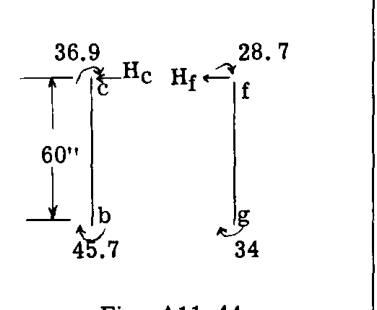

Fig. A11.44

線cfにおける外部トラスせん断力は $20 \text{ lb.}$ です。したがって、 $20 \text{ lb.}$ のせん断反力を発生させるためには、最終的な曲げモーメントは Fig. A11.43 で求められた値の $20/2.422 = 8.25$ 倍になります。したがって、最終的なモーメントは Fig. A11.43 の値の $8.25$ 倍になります。

上記で提示された解法は、剛性および到達率の値に対する軸荷重の影響を無視しています。Art. A11.12 では、これらの影響を含める方法を説明しています。

## A11.12 モーメント分配に対する軸荷重の影響

前述の項目では、連続構造物の部材端部モーメントに対する軸荷重の影響は無視されていました。軸荷重は、連続構造物の部材に次の2つの方法で曲げを引き起こします。（1）軸荷重による様々な部材の短縮または伸長は、構造物の節点の移動を引き起こします。連続性のために節点における部材間の角度は同一に保たれるため、この節点の移動は節点間の部材を曲げます。（2）外部節点荷重、横荷重、または節点回転による部材の曲げモーメントは、節点間の部材に横方向のたわみを生じさせます。部材の軸荷重にこれらの横方向たわみを乗じることで、二次モーメントが発生します。これらの二次モーメントはモーメント分配の一般的方法で処理できますが、剛性および到達率、ならびに固定端モーメントは一定ではなく、軸荷重の関数になります。

Fig. A11.45 は、Aで単純支持され、Bで固定され、Aにモーメント $M_A$ が作用し、軸圧縮荷重 $P$ を受ける角柱梁を示しています。部分図a、b、cは、梁のモーメント図を構成する3つの部分を示しています。軸荷重 $P$ がなければ、部分（c）は省略されます。

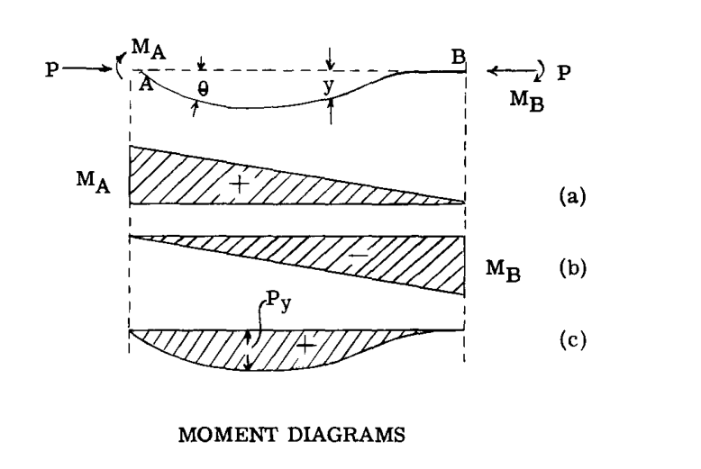

Fig. A11.45

定義により、梁ABの剛性係数は、点Aにおける弾性線の単位回転（ $\theta = 1$ ）を生じさせるために必要なモーメント $M_A$ によって測定されます。モーメント面積の原理により、Aにおける傾斜は、単純支持梁AおよびBに荷重として作用するモーメント図によるAにおけるせん断力に等しくなります。Aにおける与えられた単位傾斜に対して、荷重 $P$ が作用している場合、必要な $M_A$ がより小さくなることは明らかです。これは、荷重 $P$ が（Fig. c）において $M_A$ によるモーメント荷重と同じ符号のモーメント荷重を発生させるためです。したがって、ABの剛性は、軸圧縮荷重を受けている場合、それがない場合と比較して小さくなります。引張軸荷重の場合、モーメント図Cは負のモーメント図となり、したがってAにおいて単位傾斜を与えるためには $M_A$ がより大きくなければなりません。言い換えれば、引張軸荷重を受ける部材は、軸荷重のない部材よりも大きな剛性を持ちます。 $P$ によるモーメント図が、任意の固定端モーメントおよび到達率の大きさにも影響を及ぼすことは明らかです。

All.23

## A11.13 断面一定の梁-柱の固定端モーメント、剛性および到達率

固定端モーメント、剛性、および到達率の式を導出するには、傾斜、たわみ、およびモーメントを求める際に、Chapter A5 の梁-柱の公式を使用しなければなりません。

スタンフォード大学の B. W. James 氏は、その優れた学位論文（後に N.A.C.A. から Technical Note #534 として発行）において、これらの係数の式を導出し、実務設計で使用するためのこれらの係数のグラフを提供しました。Fig. A11.46 から Fig. A11.56 までの図は、この論文から引用されたものです。これらの図の使用方法は、いくつかの問題の解決によって最もよく説明できます。

## A11.14 例題

### 例題 12

Fig. A11.57 は、例題4（および解答2）で使用されたものと同じ連続梁を示しています。この例題では、スパンBCおよびCDにおいて、これらのスパンの項 $L/j$ がそれぞれ 2.5 および 2.0 になるような軸圧縮荷重が存在すると仮定されています。ここで $j = \sqrt{EI/P}$ です。軸荷重により、剛性と到達モーメントの新しい値、および固定端モーメントを以下のように決定しなければなりません。

[figure not shown]

Fig. A11.46

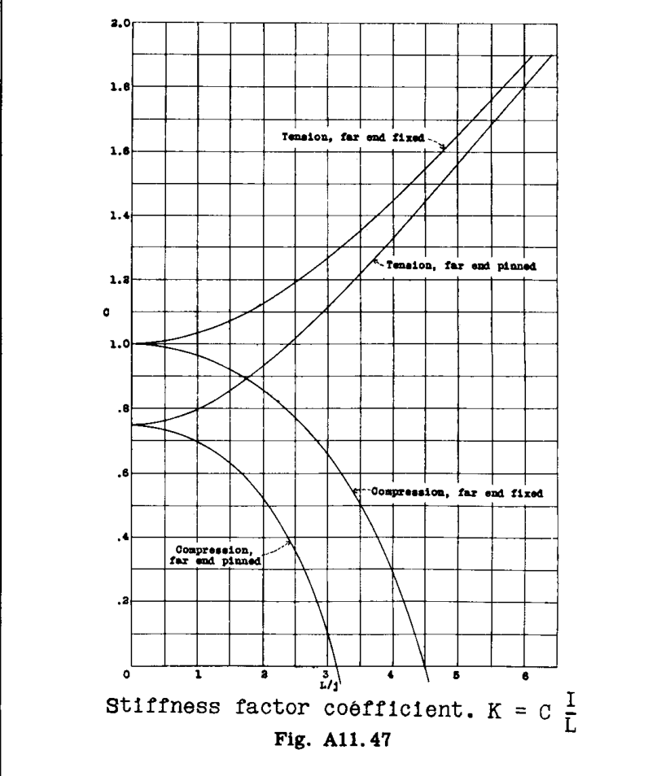

Fig. A11.47

**スパン BC**

$$K = \frac{I}{L} = \frac{1}{96} = .0104$$

Fig. A11.47 から、 $L/j = 2.5$ のとき、剛性係数の補正係数は、他端が固定の場合は $.775$ 、他端がピン支持の場合は $.36$ となります。したがって、

$$K_{BC} = .0104 \times .775 = .00806$$

$$K_{CB} = .0104 \times .36 = .00374$$

Fig. A11.46 から、 $L/j = 2.5$ のとき、到達率は $C_{BC} = .73$ 、またBが自由に支持されているとみなされる場合は $C_{CB} = 0$ となります。

Fig. A11.48 から、 $L/j = 2.5$ のとき、等分布荷重に対する固定端モーメントは $= wL^2 / 10.67 = 1 \times 96^2 / 10.67 = 865 \text{ in. lb.}$ となります。

**スパン CD**

$$K = I/L = 1/72 = .0139, \quad L/j = 2.0$$

Fig. A11.47 から、補正係数 $= .86$ 、したがって、

$$K_{CD} = K_{DC} = .86 \times .0139 = .01198$$

Fig. A11.46 からの到達率 $= .62$ 。Fig. A11.48 からの固定端モーメント $= wL^2 / 11.2 = 1 \times 72^2 / 11.2 = 462$ 。

節点Cにおける分配率は、CBに対して $(.00374 / (.00374 + .01198)) = .238$ 、残りの $.762$ がCDに対してとなります。

釣合わせおよび到達のプロセスは、例題4と同様です。

All.24 モーメント分配法

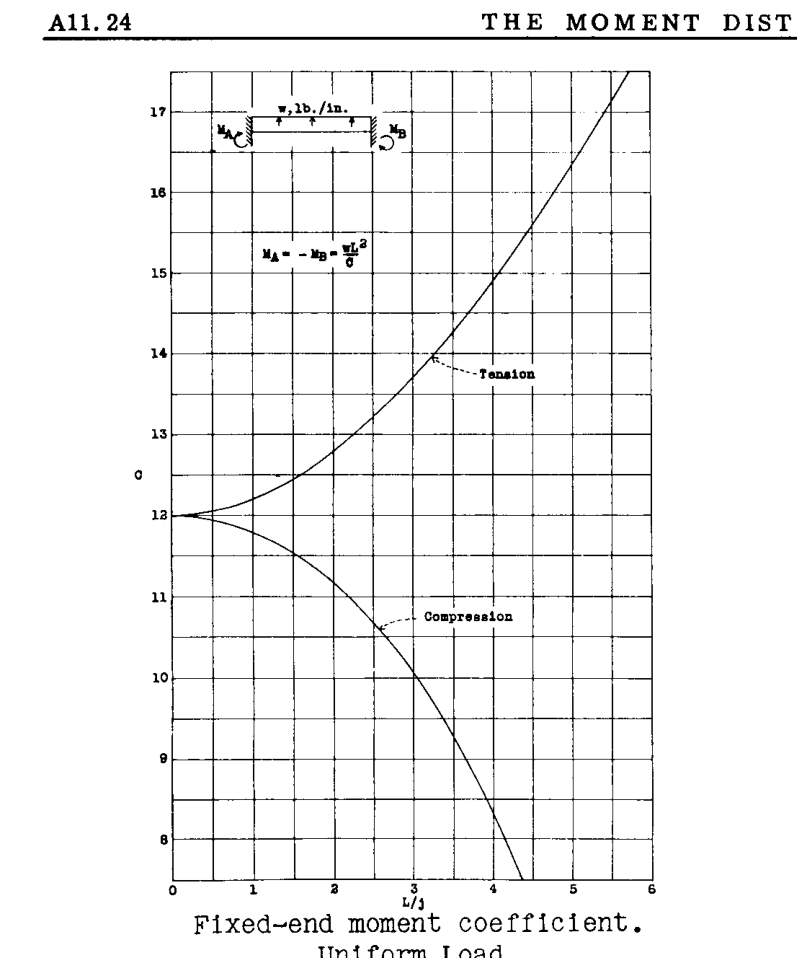

Fig. A11.48

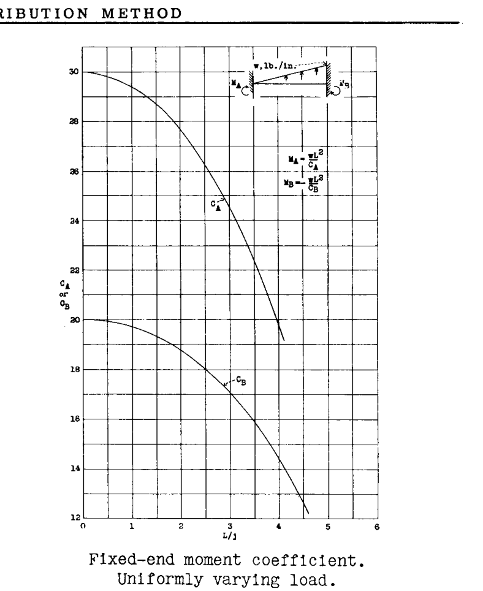

Fig. A11.49

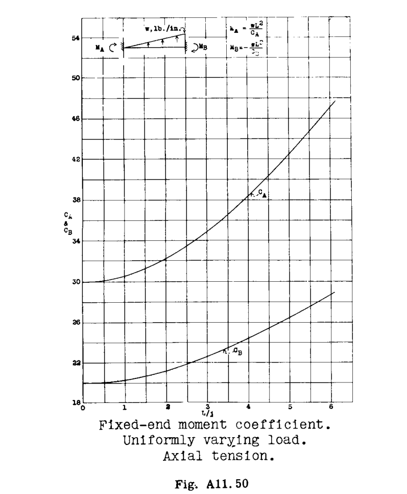

Fig. A11.50

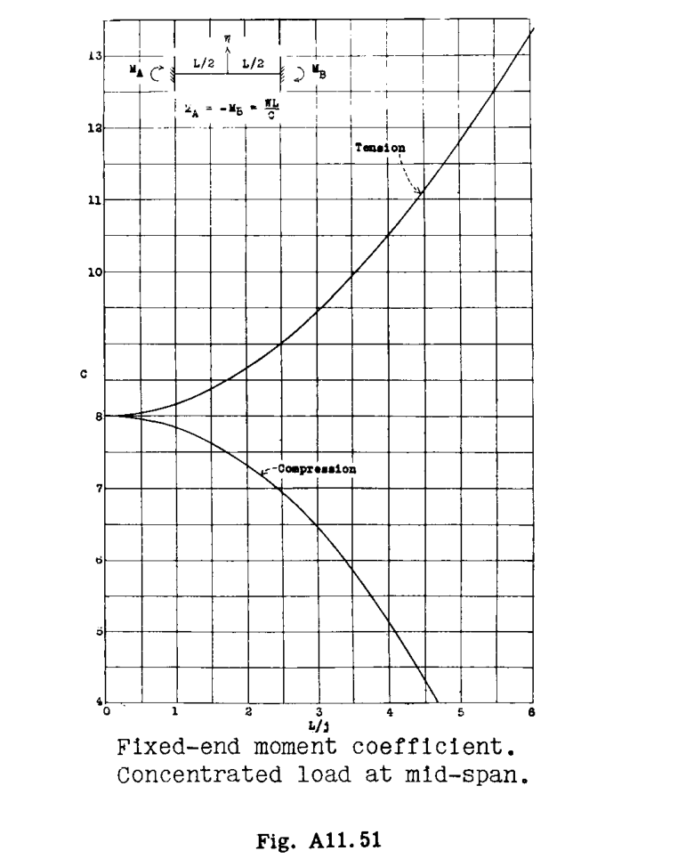

Fig. A11.51

All.25

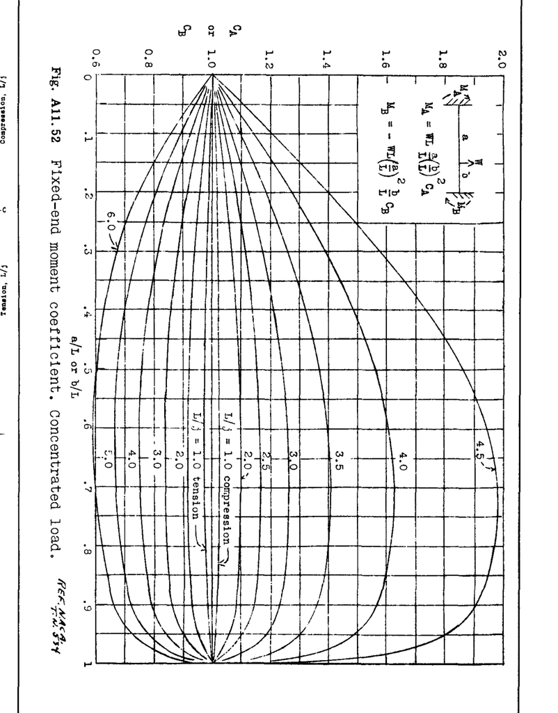

Fig. A11.52

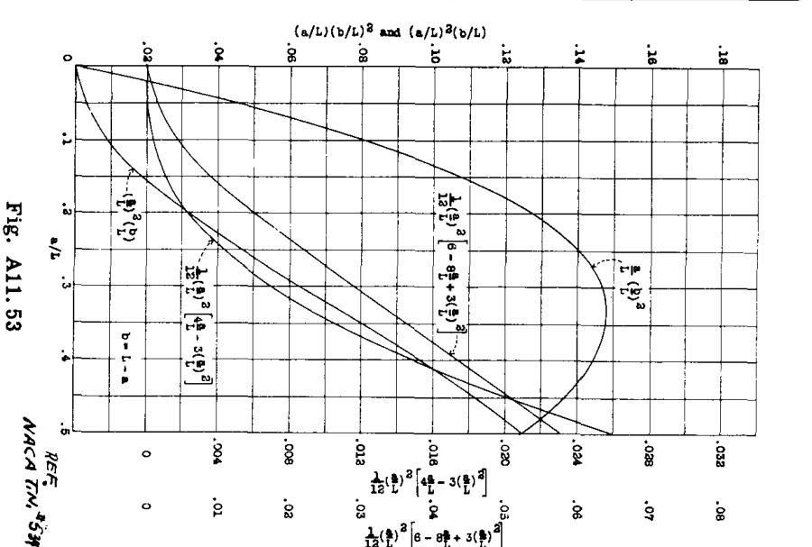

Fig. A11.53

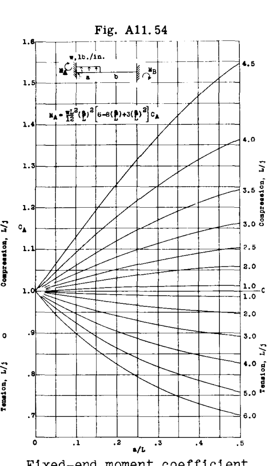

Fig. A11.54

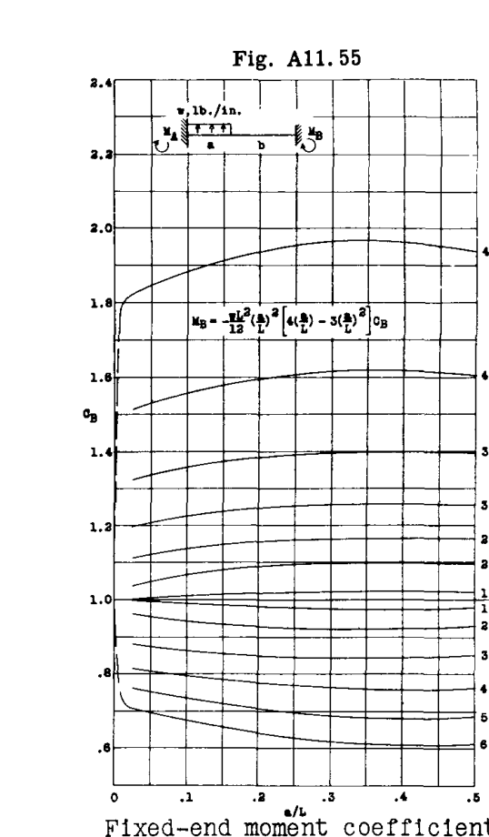

Fig. A11.55

All.26 モーメント分配法

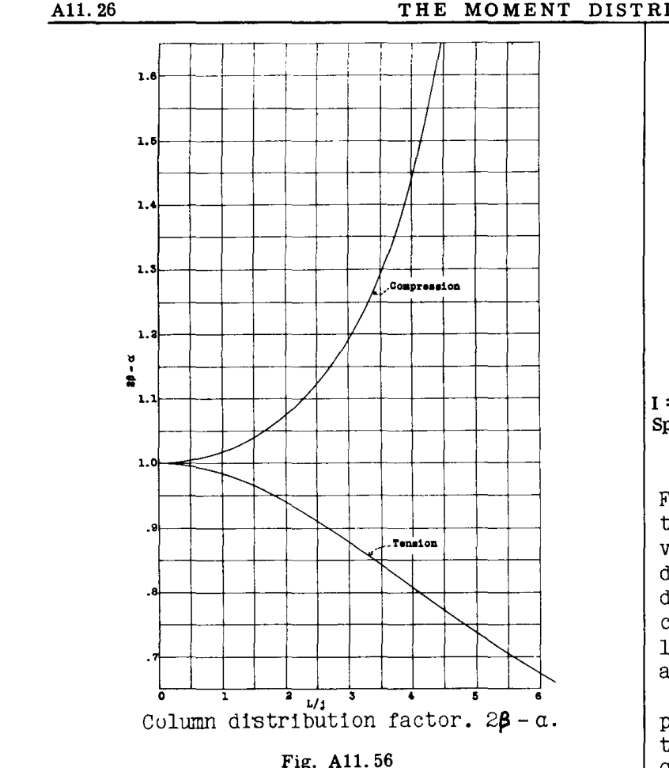

Fig. A11.56

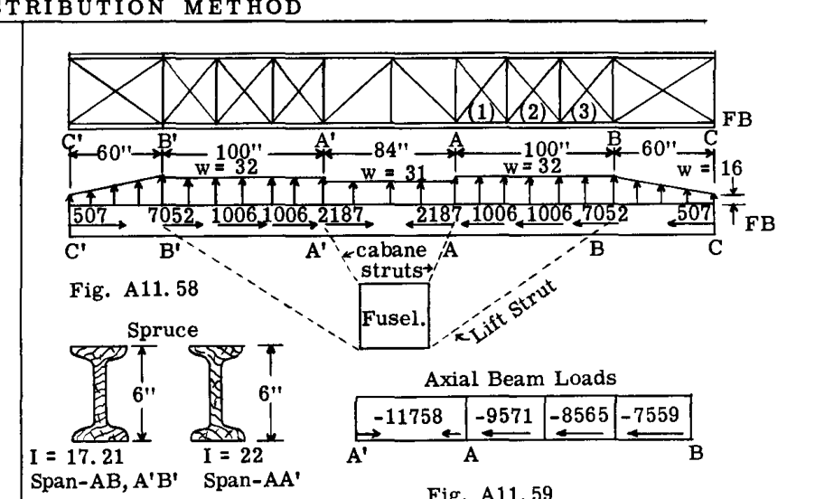

Fig. A11.58

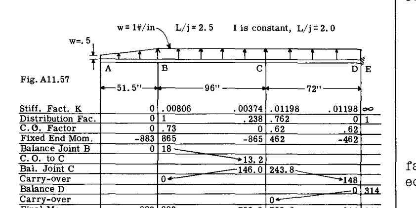

Fig. A11.57